# ASSESSING THE CORRELATES OF SELF REPORTED HEALTH AMONG THE CANADIAN RESIDENTS

# Data

The data set is a General Social Survey data- related to Canadian families. The variables in the data includes information related to family origins, conjugal and parental history (chronology of marriages, common-law unions and children), children's home leaving, and other socioeconomic characteristics. The study targeted the population of all non-institutionalized persons 15 years of age or older, residing in the 10 provinces of Canada. The data was collected using a survey developed and administered questionnaire based on research and extensive liaison with key partners and data users. A pilot study study was carried out with respondents in two cities, selected in based on representative criteria. From the pilot, the Questions were fashioned in a manner that would ensure collecting important information required for the study with utmost efficiency. The sampling followed a cross-sectional design. The utility of the collected information lies greatly with program and policy areas such as childcare strategies, parental benefits, child custody and spousal support programs as well means-tested allocations. The data set had over 20,000 observations which makes it appropriates for use in deriving some generalizations about the population. The study based on the GSS survey data is generalizable to the target population if the non-response bias is ignored.

```r
gss=read.csv("D:\\Downloads\\gss.csv")
head(gss)
```

|  | caseid | age | age_first_child | age_youngest_child_under_6 | total_children | age_start_relationship | age_at_first_marriage | age_at_first_birth | distance_between_houses | age_youngest_child_returned_work | feelings_life | sex | place_birth_canada | place_birth_father | place_birth_mother | place_birth_macro_region | place_birth_province | year_arrived_canada | province | region | pop_center | marital_status | aboriginal | vis_minority | age_immigration | landed_immigrant | citizenship_status | education | own_rent | … |
| --- | --- | --- | --- | --- | --- | --- | --- | --- | --- | --- | --- | --- | --- | --- | --- | --- | --- | --- | --- | --- | --- | --- | --- | --- | --- | --- | --- | --- | --- | --- |
| 1 | 1 | 52.7 | 27 | NA | 1 | NA | NA | 25.9 | 30 | NA | 8 | Female | Born in Canada | Born in Canada | Born in Canada | NA | Quebec | NA | Quebec | Quebec | Larger urban population centres (CMA/CA) | Single, never married | No | Not a visible minority | NA | NA | By birth | High school diploma or a high school equivalency certificate | Owned by you or a member of this household, even if it i... | … |
| 2 | 2 | 51.1 | 33 | NA | 5 | NA | NA | NA | NA | NA | 10 | Male | Born in Canada | Born in Canada | Born in Canada | NA | Ontario | NA | Manitoba | Prairie region | Larger urban population centres (CMA/CA) | Married | No | Not a visible minority | NA | NA | By birth | Trade certificate or diploma | Owned by you or a member of this household, even if it i... | … |
| 3 | 3 | 63.6 | 40 | NA | 5 | NA | NA | 23.2 | NA | NA | 8 | Female | Born in Canada | Born in Canada | Born in Canada | NA | Ontario | NA | Ontario | Ontario | Rural areas and small population centres (non CMA/CA) | Married | No | Not a visible minority | NA | NA | By birth | Bachelor's degree (e.g. B.A., B.Sc., LL.B.) | Owned by you or a member of this household, even if it i... | … |
| 4 | 4 | 80.0 | 56 | NA | 1 | NA | NA | 27.3 | NA | NA | 10 | Female | Born in Canada | Born outside Canada | Born outside Canada | NA | Alberta | NA | Alberta | Prairie region | Larger urban population centres (CMA/CA) | Married | No | Not a visible minority | NA | NA | By birth | High school diploma or a high school equivalency certificate | Owned by you or a member of this household, even if it i... | … |
| 5 | 5 | 28.0 | NA | NA | 0 | 25.3 | NA | NA | NA | NA | 8 | Male | Born in Canada | Born in Canada | Born in Canada | NA | Quebec | NA | Quebec | Quebec | Larger urban population centres (CMA/CA) | Living common-law | No | Not a visible minority | NA | NA | By birth | College, CEGEP or other non-university certificate or di... | Rented, even if no cash rent is paid | … |
| 6 | 6 | 63.0 | 37 | NA | 2 | NA | NA | 25.8 | NA | NA | 9 | Female | Born in Canada | Born in Canada | Born in Canada | NA | Quebec | NA | Quebec | Quebec | Larger urban population centres (CMA/CA) | Married | No | Not a visible minority | NA | NA | By birth | High school diploma or a high school equivalency certificate | Owned by you or a member of this household, even if it i... | … |

# Exploratory Data Analysis

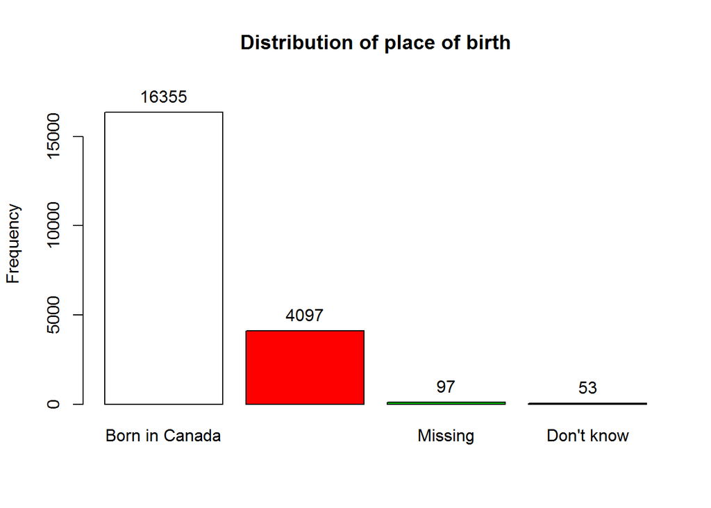

```
## gss$place_birth_canada :
##                     Frequency   %(NA+) cum.%(NA+)   %(NA-) cum.%(NA-)
## Born in Canada          16355     79.4       79.4     79.8       79.8
## Born outside Canada      4097     19.9       99.3     20.0       99.7
## NA's                       97      0.5      100.0      0.0      100.0
## Don't know                 53      0.3       99.5      0.3      100.0
##   Total                 20602    100.0      100.0    100.0      100.0
```

```r
library(epiDisplay)
tab1(gss$place_birth_canada, sort.group = "decreasing", cum.percent = TRUE,main = "Distribution of place of birth")
```

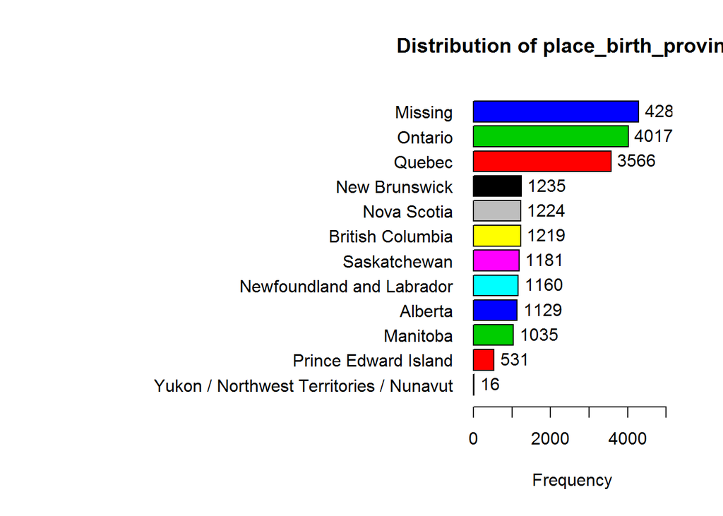

```
## gss$place_birth_province :
##                                         Frequency   %(NA+) cum.%(NA+)   %(NA-)
## NA's                                         4289     20.8      100.0      0.0
## Ontario                                      4017     19.5       53.5     24.6
## Quebec                                       3566     17.3       73.4     21.9
## New Brunswick                                1235      6.0       22.4      7.6
## Nova Scotia                                  1224      5.9       34.0      7.5
## British Columbia                             1219      5.9       11.4      7.5
## Saskatchewan                                 1181      5.7       79.1      7.2
## Newfoundland and Labrador                    1160      5.6       28.0      7.1
## Alberta                                      1129      5.5        5.5      6.9
## Manitoba                                     1035      5.0       16.4      6.3
## Prince Edward Island                          531      2.6       56.1      3.3
## Yukon / Northwest Territories / Nunavut        16      0.1       79.2      0.1
##   Total                                     20602    100.0      100.0    100.0
##                                         cum.%(NA-)
## NA's                                         100.0
## Ontario                                       67.5
## Quebec                                        92.7
## New Brunswick                                 28.3
## Nova Scotia                                   42.9
## British Columbia                              14.4
## Saskatchewan                                  99.9
## Newfoundland and Labrador                     35.4
## Alberta                                        6.9
## Manitoba                                      20.7
## Prince Edward Island                          70.8
## Yukon / Northwest Territories / Nunavut      100.0
##   Total                                      100.0
```

```r
tab1(gss$place_birth_province, sort.group = "decreasing", cum.percent = TRUE,main = "Distribution of place_birth_province")
```

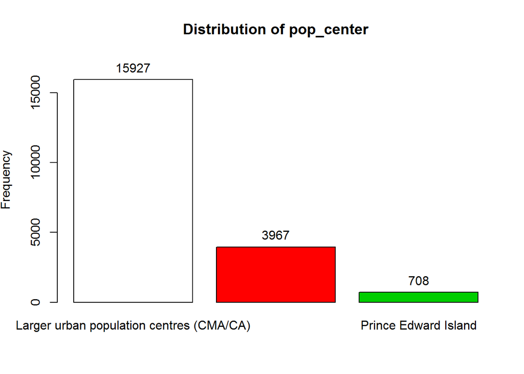

```
## gss$pop_center :
##                                                       Frequency Percent
## Larger urban population centres (CMA/CA)                  15927    77.3
## Rural areas and small population centres (non CMA/CA)      3967    19.3
## Prince Edward Island                                        708     3.4
##   Total                                                   20602   100.0
##                                                       Cum. percent
## Larger urban population centres (CMA/CA)                      77.3
## Rural areas and small population centres (non CMA/CA)         96.6
## Prince Edward Island                                         100.0
##   Total                                                      100.0
```

```r
tab1(gss$pop_center, sort.group = "decreasing", cum.percent = TRUE,main = "Distribution of pop_center")
```

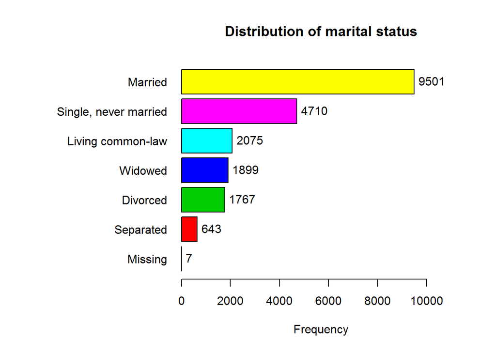

```
## gss$marital_status :
##                       Frequency   %(NA+) cum.%(NA+)   %(NA-) cum.%(NA-)
## Married                    9501     46.1       64.8     46.1       64.8
## Single, never married      4710     22.9       90.7     22.9       90.8
## Living common-law          2075     10.1       18.6     10.1       18.7
## Widowed                    1899      9.2      100.0      9.2      100.0
## Divorced                   1767      8.6        8.6      8.6        8.6
## Separated                   643      3.1       67.9      3.1       67.9
## NA's                          7      0.0      100.0      0.0      100.0
##   Total                   20602    100.0      100.0    100.0      100.0
```

```r
tab1(gss$marital_status, sort.group = "decreasing", cum.percent = TRUE,main = "Distribution of marital status")
```

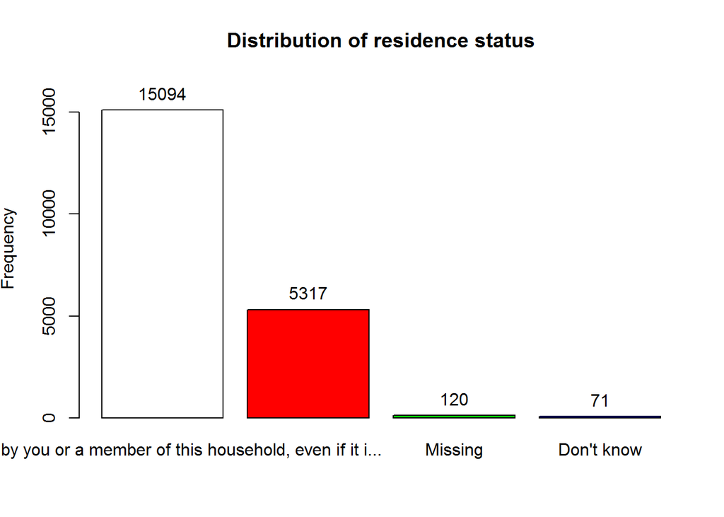

```
## gss$own_rent :
##                                                             Frequency   %(NA+)
## Owned by you or a member of this household, even if it i...     15094     73.3
## Rented, even if no cash rent is paid                             5317     25.8
## NA's                                                              120      0.6
## Don't know                                                         71      0.3
##   Total                                                         20602    100.0
##                                                             cum.%(NA+)   %(NA-)
## Owned by you or a member of this household, even if it i...       73.6     73.7
## Rented, even if no cash rent is paid                              99.4     26.0
## NA's                                                             100.0      0.0
## Don't know                                                         0.3      0.3
##   Total                                                          100.0    100.0
##                                                             cum.%(NA-)
## Owned by you or a member of this household, even if it i...       74.0
## Rented, even if no cash rent is paid                             100.0
## NA's                                                             100.0
## Don't know                                                         0.3
##   Total                                                          100.0
```

```r
tab1(gss$own_rent, sort.group = "decreasing", cum.percent = TRUE,main = "Distribution of residence status")
```

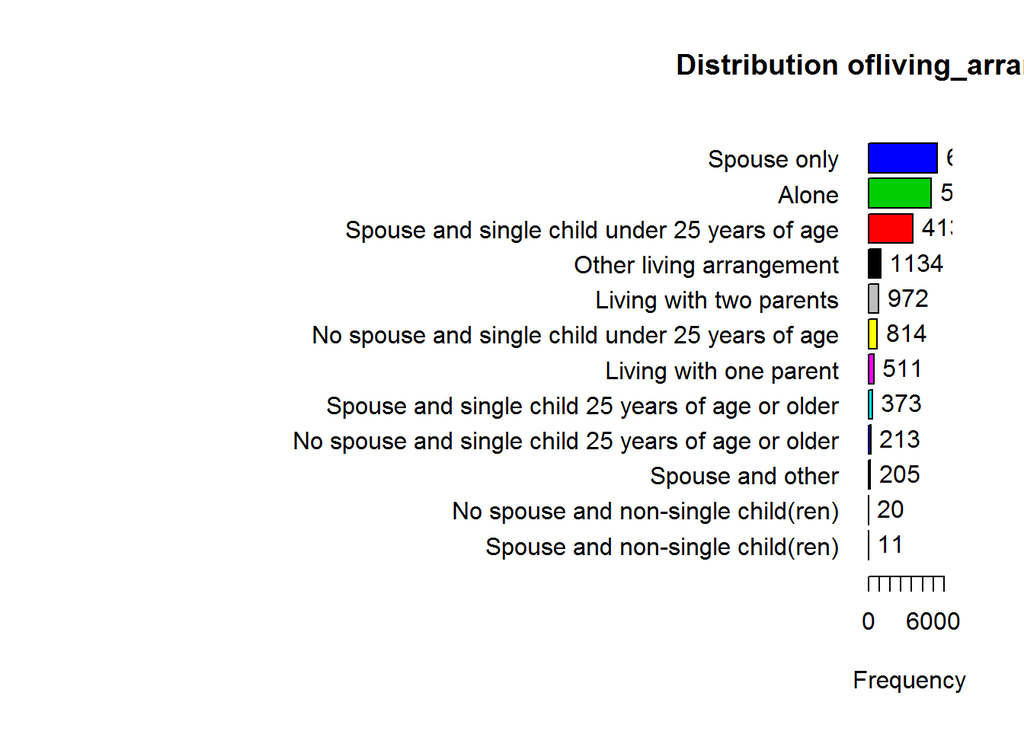

```
## gss$living_arrangement :
##                                                     Frequency Percent
## Spouse only                                              6398    31.1
## Alone                                                    5815    28.2
## Spouse and single child under 25 years of age            4136    20.1
## Other living arrangement                                 1134     5.5
## Living with two parents                                   972     4.7
## No spouse and single child under 25 years of age          814     4.0
## Living with one parent                                    511     2.5
## Spouse and single child 25 years of age or older          373     1.8
## No spouse and single child 25 years of age or older       213     1.0
## Spouse and other                                          205     1.0
## No spouse and non-single child(ren)                        20     0.1
## Spouse and non-single child(ren)                           11     0.1
##   Total                                                 20602   100.0
##                                                     Cum. percent
## Spouse only                                                 31.1
## Alone                                                       59.3
## Spouse and single child under 25 years of age               79.4
## Other living arrangement                                    84.9
## Living with two parents                                     89.6
## No spouse and single child under 25 years of age            93.5
## Living with one parent                                      96.0
## Spouse and single child 25 years of age or older            97.8
## No spouse and single child 25 years of age or older         98.9
## Spouse and other                                            99.8
## No spouse and non-single child(ren)                         99.9
## Spouse and non-single child(ren)                           100.0
##   Total                                                    100.0
```

```r
tab1(gss$living_arrangement, sort.group = "decreasing", cum.percent = TRUE,main = "Distribution ofliving_arrangement")
```

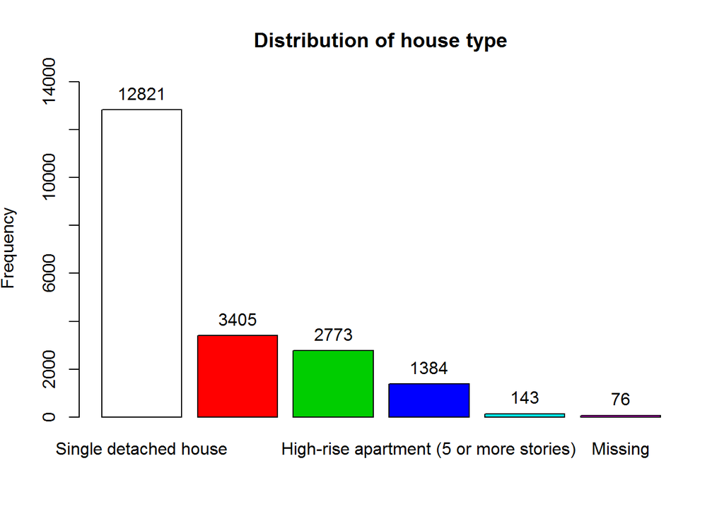

```
## gss$hh_type :
##                                          Frequency   %(NA+) cum.%(NA+)   %(NA-)
## Single detached house                        12821     62.2       99.6     62.5
## Other                                         3405     16.5       37.4     16.6
## Low-rise apartment (less than 5 stories)      2773     13.5       20.9     13.5
## High-rise apartment (5 or more stories)       1384      6.7        7.4      6.7
## Don't know                                     143      0.7        0.7      0.7
## NA's                                            76      0.4      100.0      0.0
##   Total                                      20602    100.0      100.0    100.0
##                                          cum.%(NA-)
## Single detached house                         100.0
## Other                                          37.5
## Low-rise apartment (less than 5 stories)       20.9
## High-rise apartment (5 or more stories)         7.4
## Don't know                                      0.7
## NA's                                          100.0
##   Total                                       100.0
```

```r
tab1(gss$hh_type, sort.group = "decreasing", cum.percent = TRUE,main = "Distribution of house type")
```